# 02_Tratamiento_correlaciones_missing_outlier

## Importo librerias

```python
import pandas as pd
import numpy as np
import seaborn as sns
from matplotlib import pyplot as plt
import plotly.express as px
from sklearn.impute import KNNImputer
import scipy.stats as ss
import warnings

pd.set_option('display.max_columns', 500)
pd.set_option('display.max_rows', 5000)
```

## Funciones

```python
def plot_feature(df, col_name, isContinuous, target):
    """
    Visualize a variable with and without faceting on the BAF status.
    - df dataframe
    - col_name is the variable name in the dataframe
    - full_name is the full variable name
    - continuous is True if the variable is continuous, False otherwise
    """
    f, (ax1, ax2) = plt.subplots(nrows=1, ncols=2, figsize=(12,3), dpi=90)

    count_null = df[col_name].isnull().sum()
    if isContinuous:

        sns.histplot(df.loc[df[col_name].notnull(), col_name], kde=False, ax=ax1)
    else:
        sns.countplot(df[col_name], order=sorted(df[col_name].unique()), color='#5975A4', saturation=1, ax=ax1)
    ax1.set_xlabel(col_name)
    ax1.set_ylabel('Count')
    ax1.set_title(col_name+ ' Numero de nulos: '+str(count_null))
    plt.xticks(rotation = 90)


    if isContinuous:
        sns.boxplot(x=col_name, y=target, data=df, ax=ax2)
        ax2.set_ylabel('')
        ax2.set_title(col_name + ' by '+target)
    else:
        data = df.groupby(col_name)[target].value_counts(normalize=True).to_frame('proportion').reset_index()
        data.columns = [i, target, 'proportion']
        #sns.barplot(x = col_name, y = 'proportion', hue= target, data = data, saturation=1, ax=ax2)
        sns.barplot(x = col_name, y = 'proportion', hue= target, data = data, saturation=1, ax=ax2)
        ax2.set_ylabel(target+' fraction')
        ax2.set_title(target)
        plt.xticks(rotation = 90)
    ax2.set_xlabel(col_name)

    plt.tight_layout()


def dame_variables_categoricas(dataset=None):
    '''
    ----------------------------------------------------------------------------------------------------------
    Función dame_variables_categoricas:
    ----------------------------------------------------------------------------------------------------------
        -Descripción: Función que recibe un dataset y devuelve una lista con los nombres de las
        variables categóricas
        -Inputs:
            -- dataset: Pandas dataframe que contiene los datos
        -Return:
            -- lista_variables_categoricas: lista con los nombres de las variables categóricas del
            dataset de entrada con menos de 100 valores diferentes
            -- 1: la ejecución es incorrecta
    '''
    if dataset is None:
        print(u'\nFaltan argumentos por pasar a la función')
        return 1
    lista_variables_categoricas = []
    other = []
    for i in dataset.columns:
        if (dataset[i].dtype!=float) & (dataset[i].dtype!=int):
            unicos = int(len(np.unique(dataset[i].dropna(axis=0, how='all'))))
            if unicos < 100:
                lista_variables_categoricas.append(i)
            else:
                other.append(i)

    return lista_variables_categoricas, other


def get_corr_matrix(dataset = None, metodo='pearson', size_figure=[10,8]):
    # Para obtener la correlación de Spearman, sólo cambiar el metodo por 'spearman'

    if dataset is None:
        print(u'\nHace falta pasar argumentos a la función')
        return 1
    sns.set(style="white")
    # Compute the correlation matrix
    corr = dataset.corr(method=metodo)
    # Set self-correlation to zero to avoid distraction
    for i in range(corr.shape[0]):
        corr.iloc[i, i] = 0
    # Set up the matplotlib figure
    f, ax = plt.subplots(figsize=size_figure)
    # Draw the heatmap with the mask and correct aspect ratio
    sns.heatmap(corr, center=0,
                square=True, linewidths=.5,  cmap ='viridis' ) #cbar_kws={"shrink": .5}
    plt.show()

    return 0

def get_deviation_of_mean_perc(pd_BAF, list_var_continuous, target, multiplier):
    """
    Devuelve el porcentaje de valores que exceden del intervalo de confianza
    :type series:
    :param multiplier:
    :return:
    """
    pd_final = pd.DataFrame()

    for i in list_var_continuous:

        series_mean = pd_BAF[i].mean()
        series_std = pd_BAF[i].std()
        std_amp = multiplier * series_std
        left = series_mean - std_amp
        right = series_mean + std_amp
        size_s = pd_BAF[i].size

        perc_goods = pd_BAF[i][(pd_BAF[i] >= left) & (pd_BAF[i] <= right)].size/size_s
        perc_excess = pd_BAF[i][(pd_BAF[i] < left) | (pd_BAF[i] > right)].size/size_s

        if perc_excess>0:
            pd_concat_percent = pd.DataFrame(pd_BAF[target][(pd_BAF[i] < left) | (pd_BAF[i] > right)]\
                                            .value_counts(normalize=True).reset_index()).T
            pd_concat_percent.columns = [pd_concat_percent.iloc[0,0],
                                         pd_concat_percent.iloc[0,1]]
            #pd_concat_percent = pd_concat_percent.drop('index',axis=0)
            pd_concat_percent['variable'] = i
            pd_concat_percent['sum_outlier_values'] = pd_BAF[i][(pd_BAF[i] < left) | (pd_BAF[i] > right)].size
            pd_concat_percent['porcentaje_sum_null_values'] = perc_excess
            pd_final = pd.concat([pd_final, pd_concat_percent], axis=0).reset_index(drop=True)

    if pd_final.empty:
        print('No existen variables con valores nulos')

    return pd_final


def get_percent_null_values_target(pd_BAF, list_var_continuous, target):

    pd_final = pd.DataFrame()
    for i in list_var_continuous:
        if pd_BAF[i].isnull().sum()>0:
            pd_concat_percent = pd.DataFrame(pd_BAF[target][pd_BAF[i].isnull()]\
                                            .value_counts(normalize=True).reset_index()).T
            pd_concat_percent.columns = [pd_concat_percent.iloc[0,0],
                                         pd_concat_percent.iloc[0,1]]
            pd_concat_percent = pd_concat_percent.drop('index',axis=0)
            pd_concat_percent['variable'] = i
            pd_concat_percent['sum_null_values'] = pd_BAF[i].isnull().sum()
            pd_concat_percent['porcentaje_sum_null_values'] = pd_BAF[i].isnull().sum()/pd_BAF.shape[0]
            pd_final = pd.concat([pd_final, pd_concat_percent], axis=0).reset_index(drop=True)

    if pd_final.empty:
        print('No existen variables con valores nulos')

    return pd_final



def cramers_v(confusion_matrix):
    """
    calculate Cramers V statistic for categorial-categorial association.
    uses correction from Bergsma and Wicher,
    Journal of the Korean Statistical Society 42 (2013): 323-328

    confusion_matrix: tabla creada con pd.crosstab()

    """
    chi2 = ss.chi2_contingency(confusion_matrix)[0]
    n = confusion_matrix.sum()
    phi2 = chi2 / n
    r, k = confusion_matrix.shape
    phi2corr = max(0, phi2 - ((k-1)*(r-1))/(n-1))
    rcorr = r - ((r-1)**2)/(n-1)
    kcorr = k - ((k-1)**2)/(n-1)
    return np.sqrt(phi2corr / min((kcorr-1), (rcorr-1)))
```

## Lectura de datos del preprocesado inicial

```python
pd_BAF = pd.read_csv("../data/data_preprocessing/pd_data_initial_preprocessing.csv")
pd_BAF.shape
```

```
(1000000, 33)
```

```python
lista_variables = list(pd_BAF.columns)
print(len(lista_variables))
print(lista_variables)
```

```
33
['Unnamed: 0', 'fraud_bool', 'income', 'device_fraud_count', 'device_distinct_emails_8w', 'keep_alive_session', 'device_os', 'session_length_in_minutes', 'source', 'foreign_request', 'proposed_credit_limit', 'has_other_cards', 'bank_months_count', 'phone_mobile_valid', 'phone_home_valid', 'housing_s…
```

```python
pd_BAF["Unnamed: 0"]
```

```
0              0
1              1
2              2
3              3
4              4
           ...
999995    999995
999996    999996
999997    999997
999998    999998
999999    999999
Name: Unnamed: 0, Length: 1000000, dtype: int64
```

```python
pd_BAF = pd_BAF.drop("Unnamed: 0", axis=1)
```

```python
list_var_cat, other = dame_variables_categoricas(dataset=pd_BAF)
pd_BAF[list_var_cat] = pd_BAF[list_var_cat].astype("category")
list_var_continuous = list(pd_BAF.select_dtypes('float').columns)
pd_BAF[list_var_continuous] = pd_BAF[list_var_continuous].astype(float)
pd_BAF.dtypes
```

```
fraud_bool                          category
income                               float64
device_fraud_count                  category
device_distinct_emails_8w           category
keep_alive_session                  category
device_os                           category
session_length_in_minutes            float64
source                              category
foreign_request                     category
proposed_credit_limit                float64
has_other_cards                     category
bank_months_count                   category
phone_mobile_valid                  category
phone_home_valid                    category
housing_status                      category
email_is_free                       category
credit_risk_score                      int64
employment_status                   category
date_of_birth_distinct_emails_4w    category
bank_branch_count_8w                   int64
velocity_4w                          float64
velocity_24h                         float64
velocity_6h                          float64
zip_count_4w                           int64
payment_type                        category
intended_balcon_amount               float64
days_since_request                   float64
customer_age                        category
current_address_months_count           int64
prev_address_months_count              int64
name_email_similarity                float64
month                               category
dtype: object
```

## Separación en train y test estratificado

```python
pd_plot_fraud_bool = pd_BAF\
        .value_counts(normalize=True)\
        .mul(100).rename('percent').reset_index()

pd_plot_fraud_bool_conteo = pd_BAF.value_counts().reset_index()
pd_plot_fraud_bool_pc = pd.merge(pd_plot_fraud_bool,
                                  pd_plot_fraud_bool_conteo, how='inner')

fig = px.histogram(pd_plot_fraud_bool_pc, x="fraud_bool", y=['percent'])
fig.show()
```

[output not shown]

```python
from sklearn.model_selection import train_test_split
X_pd_BAF, X_pd_BAF_test, y_pd_BAF, y_pd_BAF_test = train_test_split(pd_BAF.drop('fraud_bool',axis=1),
                                                                     pd_BAF['fraud_bool'],
                                                                     stratify=pd_BAF['fraud_bool'],
                                                                     test_size=0.2)
pd_BAF_train = pd.concat([X_pd_BAF, y_pd_BAF],axis=1)
pd_BAF_test = pd.concat([X_pd_BAF_test, y_pd_BAF_test],axis=1)
```

```python
print('== Train\n', pd_BAF_train['fraud_bool'].value_counts(normalize=True))
print('== Test\n', pd_BAF_test['fraud_bool'].value_counts(normalize=True))
```

```
== Train
 fraud_bool
0    0.988971
1    0.011029
Name: proportion, dtype: float64
== Test
 fraud_bool
0    0.98897
1    0.01103
Name: proportion, dtype: float64
```

## Visualización descriptiva de los datos

```python
pd_series_null_columns = pd_BAF_train.isnull().sum().sort_values(ascending=False)
pd_series_null_rows = pd_BAF_train.isnull().sum(axis=1).sort_values(ascending=False)
print(pd_series_null_columns.shape, pd_series_null_rows.shape)

pd_null_columnas = pd.DataFrame(pd_series_null_columns, columns=['nulos_columnas'])
pd_null_filas = pd.DataFrame(pd_series_null_rows, columns=['nulos_filas'])
pd_null_filas['target'] = pd_BAF['fraud_bool'].copy()
pd_null_columnas['porcentaje_columnas'] = pd_null_columnas['nulos_columnas']/pd_BAF_train.shape[0]
pd_null_filas['porcentaje_filas']= pd_null_filas['nulos_filas']/pd_BAF_train.shape[1]
```

```
(32,) (800000,)
```

```python
pd_null_columnas
```

|  | nulos_columnas | porcentaje_columnas |
| --- | --- | --- |
| income | 0 | 0.0 |
| device_fraud_count | 0 | 0.0 |
| month | 0 | 0.0 |
| name_email_similarity | 0 | 0.0 |
| prev_address_months_count | 0 | 0.0 |
| current_address_months_count | 0 | 0.0 |
| customer_age | 0 | 0.0 |
| days_since_request | 0 | 0.0 |
| intended_balcon_amount | 0 | 0.0 |
| payment_type | 0 | 0.0 |
| zip_count_4w | 0 | 0.0 |
| velocity_6h | 0 | 0.0 |
| velocity_24h | 0 | 0.0 |
| velocity_4w | 0 | 0.0 |
| bank_branch_count_8w | 0 | 0.0 |
| date_of_birth_distinct_emails_4w | 0 | 0.0 |
| employment_status | 0 | 0.0 |
| credit_risk_score | 0 | 0.0 |
| email_is_free | 0 | 0.0 |
| housing_status | 0 | 0.0 |
| phone_home_valid | 0 | 0.0 |
| phone_mobile_valid | 0 | 0.0 |
| bank_months_count | 0 | 0.0 |
| has_other_cards | 0 | 0.0 |
| proposed_credit_limit | 0 | 0.0 |
| foreign_request | 0 | 0.0 |
| source | 0 | 0.0 |
| session_length_in_minutes | 0 | 0.0 |
| device_os | 0 | 0.0 |
| keep_alive_session | 0 | 0.0 |
| device_distinct_emails_8w | 0 | 0.0 |
| fraud_bool | 0 | 0.0 |

```python
pd_null_filas
```

|  | nulos_filas | target | porcentaje_filas |
| --- | --- | --- | --- |
| 880113 | 0 | 0 | 0.0 |
| 219055 | 0 | 0 | 0.0 |
| 992900 | 0 | 0 | 0.0 |
| 243532 | 0 | 0 | 0.0 |
| 319642 | 0 | 0 | 0.0 |
| ... | ... | ... | ... |
| 372477 | 0 | 0 | 0.0 |
| 288182 | 0 | 0 | 0.0 |
| 519226 | 0 | 0 | 0.0 |
| 357583 | 0 | 0 | 0.0 |
| 562054 | 0 | 0 | 0.0 |

800000 rows × 3 columns

#### Distribución del resto de variables

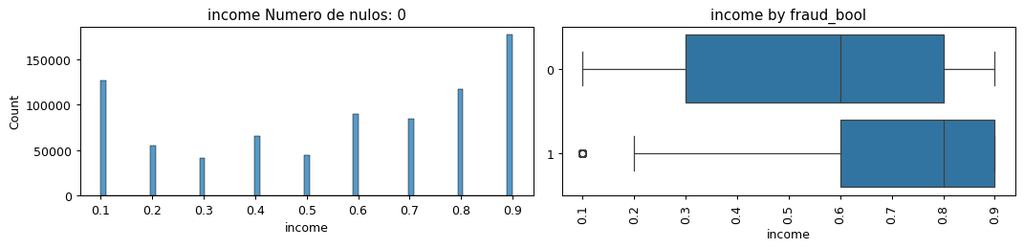

```python
plot_feature(pd_BAF_train, col_name="income", isContinuous=True, target='fraud_bool')
```

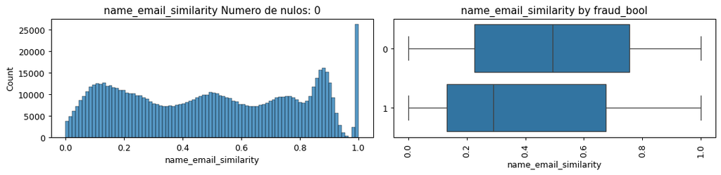

```python
plot_feature(pd_BAF_train, col_name="name_email_similarity", isContinuous=True, target='fraud_bool')
```

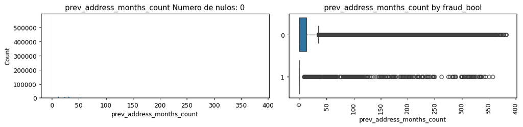

```python
plot_feature(pd_BAF_train, col_name="prev_address_months_count", isContinuous=True, target='fraud_bool')
```

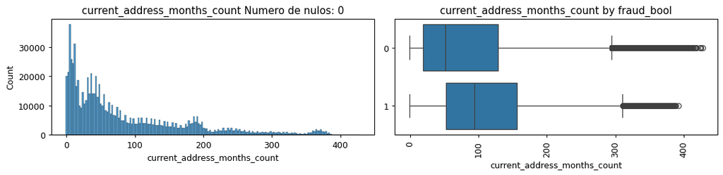

```python
plot_feature(pd_BAF_train, col_name="current_address_months_count", isContinuous=True, target='fraud_bool')
```

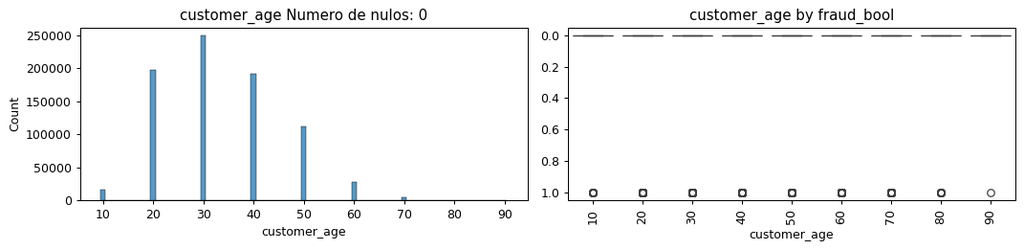

```python
plot_feature(pd_BAF_train, col_name="customer_age", isContinuous=True, target='fraud_bool')
```

```python
#plot_feature(pd_BAF_train, col_name="days_since_request", isContinuous=True, target='fraud_bool')
```

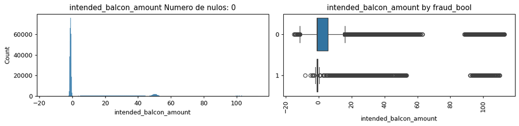

```python
plot_feature(pd_BAF_train, col_name="intended_balcon_amount", isContinuous=True, target='fraud_bool')
```

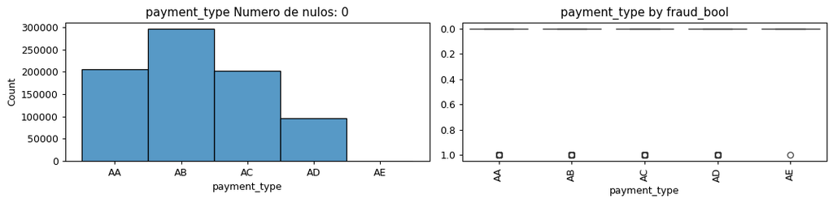

```python
plot_feature(pd_BAF_train, col_name="payment_type", isContinuous=True, target='fraud_bool')
```

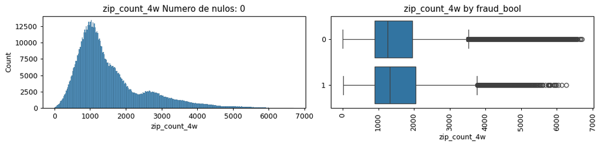

```python
plot_feature(pd_BAF_train, col_name="zip_count_4w", isContinuous=True, target='fraud_bool')
```

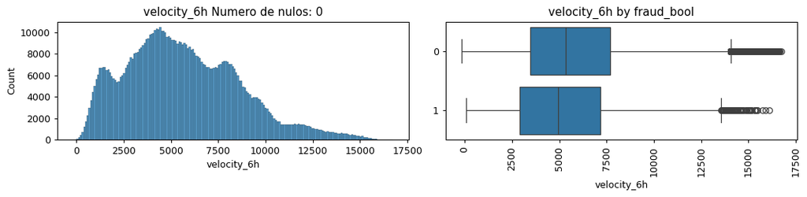

```python
plot_feature(pd_BAF_train, col_name="velocity_6h", isContinuous=True, target='fraud_bool')
```

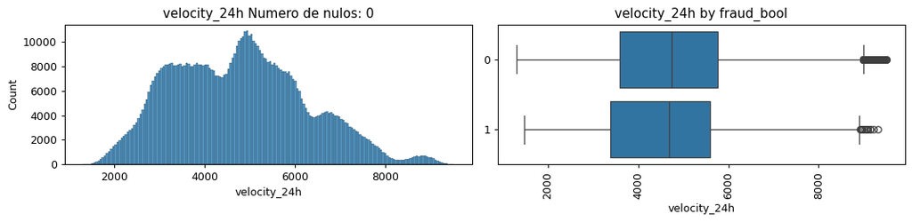

```python
plot_feature(pd_BAF_train, col_name="velocity_24h", isContinuous=True, target='fraud_bool')
```

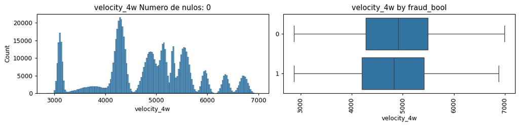

```python
plot_feature(pd_BAF_train, col_name="velocity_4w", isContinuous=True, target='fraud_bool')
```

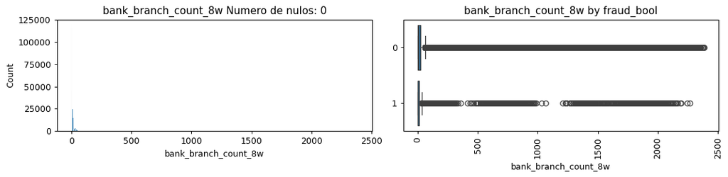

```python
plot_feature(pd_BAF_train, col_name="bank_branch_count_8w", isContinuous=True, target='fraud_bool')
```

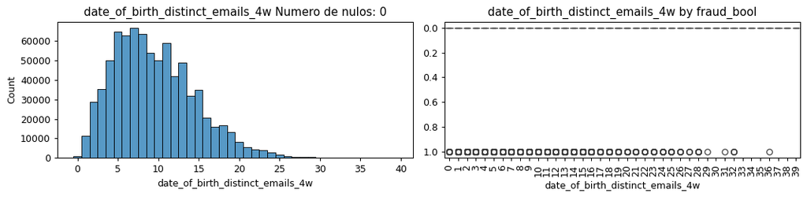

```python
plot_feature(pd_BAF_train, col_name="date_of_birth_distinct_emails_4w", isContinuous=True, target='fraud_bool')
```

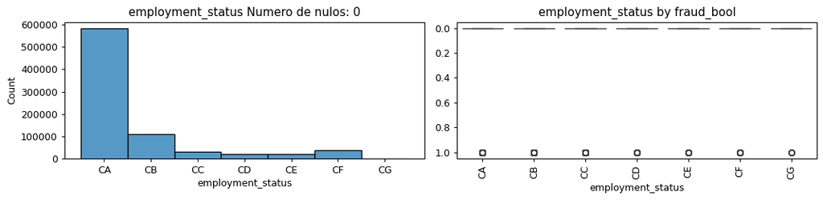

```python
plot_feature(pd_BAF_train, col_name="employment_status", isContinuous=True, target='fraud_bool')
```

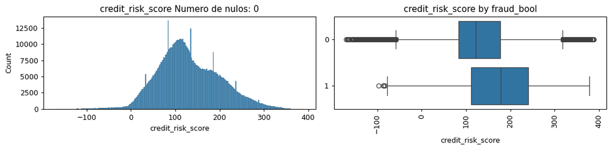

```python
plot_feature(pd_BAF_train, col_name="credit_risk_score", isContinuous=True, target='fraud_bool')
```

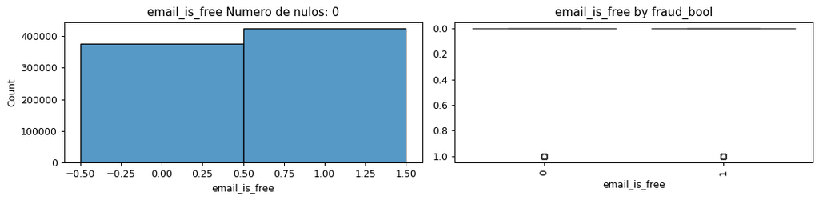

```python
plot_feature(pd_BAF_train, col_name="email_is_free", isContinuous=True, target='fraud_bool')
```

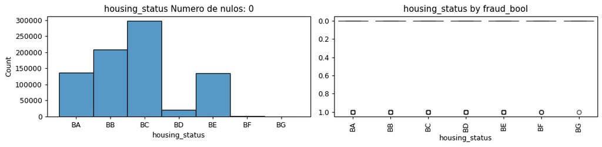

```python
plot_feature(pd_BAF_train, col_name="housing_status", isContinuous=True, target='fraud_bool')
```

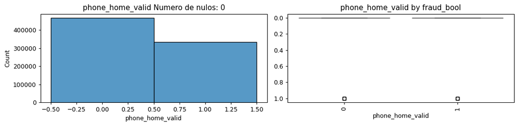

```python
plot_feature(pd_BAF_train, col_name="phone_home_valid", isContinuous=True, target='fraud_bool')
```

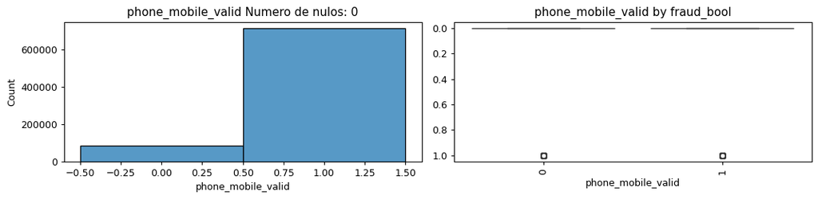

```python
plot_feature(pd_BAF_train, col_name="phone_mobile_valid", isContinuous=True, target='fraud_bool')
```

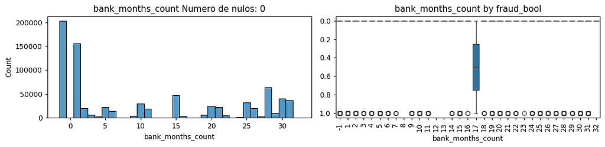

```python
plot_feature(pd_BAF_train, col_name="bank_months_count", isContinuous=True, target='fraud_bool')
```

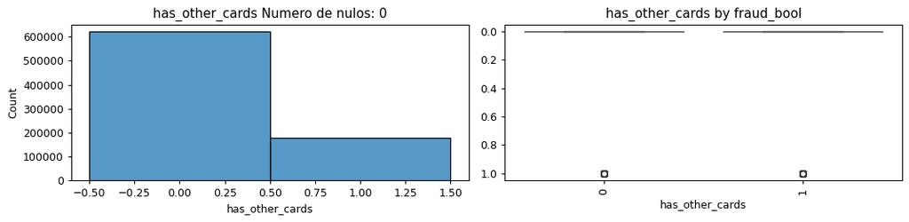

```python
plot_feature(pd_BAF_train, col_name="has_other_cards", isContinuous=True, target='fraud_bool')
```

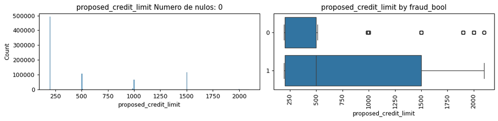

```python
plot_feature(pd_BAF_train, col_name="proposed_credit_limit", isContinuous=True, target='fraud_bool')
```

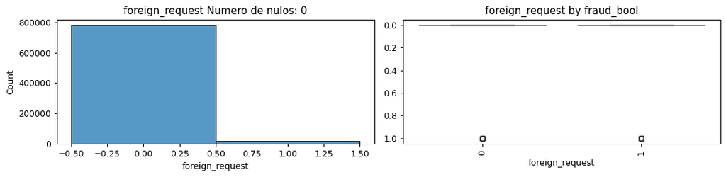

```python
plot_feature(pd_BAF_train, col_name="foreign_request", isContinuous=True, target='fraud_bool')
```

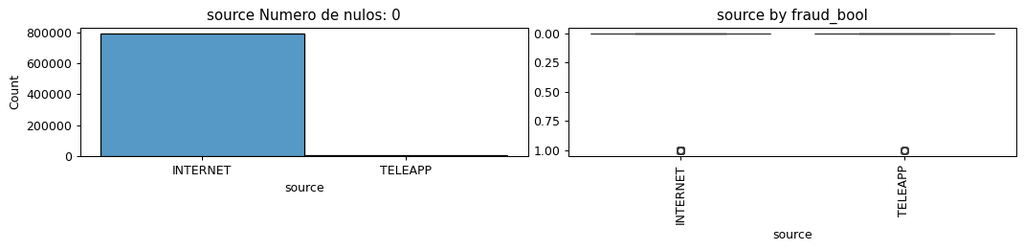

```python
plot_feature(pd_BAF_train, col_name="source", isContinuous=True, target='fraud_bool')
```

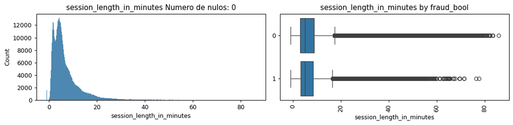

```python
plot_feature(pd_BAF_train, col_name="session_length_in_minutes", isContinuous=True, target='fraud_bool')
```

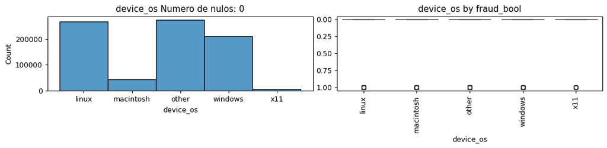

```python
plot_feature(pd_BAF_train, col_name="device_os", isContinuous=True, target='fraud_bool')
```

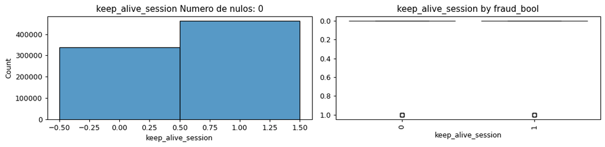

```python
plot_feature(pd_BAF_train, col_name="keep_alive_session", isContinuous=True, target='fraud_bool')
```

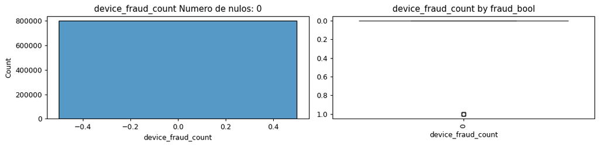

```python
plot_feature(pd_BAF_train, col_name="device_fraud_count", isContinuous=True, target='fraud_bool')
```

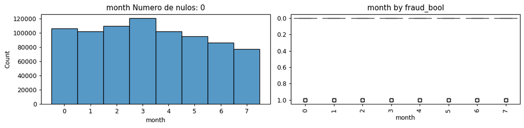

```python
plot_feature(pd_BAF_train, col_name="month", isContinuous=True, target='fraud_bool')
```

## Tratamiento de las variables continuas

```python
list_var_continuous
```

```
['income',
 'session_length_in_minutes',
 'proposed_credit_limit',
 'velocity_4w',
 'velocity_24h',
 'velocity_6h',
 'intended_balcon_amount',
 'days_since_request',
 'name_email_similarity']
```

#### Tratamiento de outliers

Los valores outlier se pueden sustituir por la media, mediana, valores extremos (media+3std o media-3std). Tras el siguiente análisis, he decidido como primera iteración dejarlos sin sustituir. Una vez llegue al modelo puedo realizar iteraciones utilizando diferentes métodos para comprobar si mejora el modelo

```python
get_deviation_of_mean_perc(pd_BAF_train, list_var_continuous, target='fraud_bool', multiplier=3)
```

|  | 0.0 | 1.0 | variable | sum_outlier_values | porcentaje_sum_null_values |
| --- | --- | --- | --- | --- | --- |
| 0 | 0.000000 | 1.000000 | session_length_in_minutes | 18933 | 0.023666 |
| 1 | 0.980880 | 0.019120 | session_length_in_minutes | 18933 | 0.023666 |
| 2 | 0.000000 | 1.000000 | proposed_credit_limit | 4888 | 0.006110 |
| 3 | 0.869272 | 0.130728 | proposed_credit_limit | 4888 | 0.006110 |
| 4 | 0.000000 | 1.000000 | velocity_24h | 426 | 0.000532 |
| 5 | 0.995305 | 0.004695 | velocity_24h | 426 | 0.000532 |
| 6 | 0.000000 | 1.000000 | velocity_6h | 3476 | 0.004345 |
| 7 | 0.993671 | 0.006329 | velocity_6h | 3476 | 0.004345 |
| 8 | 0.000000 | 1.000000 | intended_balcon_amount | 15034 | 0.018793 |
| 9 | 0.989956 | 0.010044 | intended_balcon_amount | 15034 | 0.018793 |
| 10 | 0.000000 | 1.000000 | days_since_request | 14307 | 0.017884 |
| 11 | 0.988048 | 0.011952 | days_since_request | 14307 | 0.017884 |

#### Correlaciones

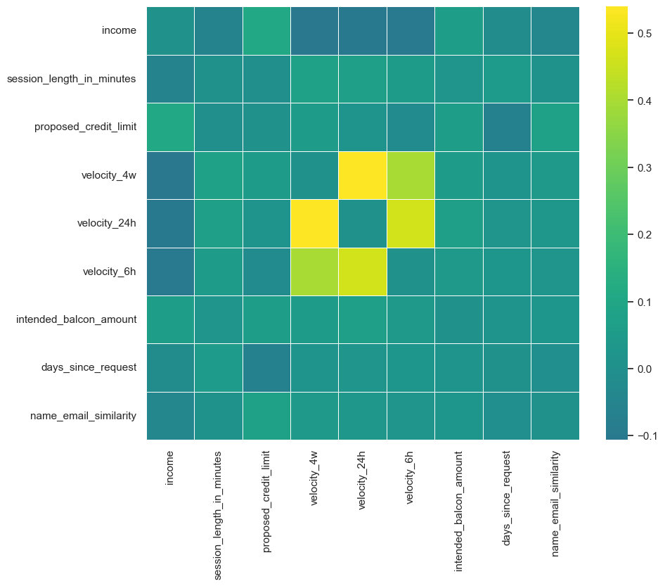

```
0
```

```python
get_corr_matrix(dataset = pd_BAF_train[list_var_continuous],
                metodo='pearson', size_figure=[10,8])
```

```python
corr = pd_BAF_train[list_var_continuous].corr('pearson')
new_corr = corr.abs()
new_corr.loc[:,:] = np.tril(new_corr, k=-1) # below main lower triangle of an array
new_corr = new_corr.stack().to_frame('correlation').reset_index().sort_values(by='correlation', ascending=False)
new_corr
```

|  | level_0 | level_1 | correlation |
| --- | --- | --- | --- |
| 39 | velocity_24h | velocity_4w | 0.539548 |
| 49 | velocity_6h | velocity_24h | 0.464571 |
| 48 | velocity_6h | velocity_4w | 0.400360 |
| 18 | proposed_credit_limit | income | 0.108650 |
| 27 | velocity_4w | income | 0.106325 |
| 36 | velocity_24h | income | 0.101976 |
| 45 | velocity_6h | income | 0.096644 |
| 28 | velocity_4w | session_length_in_minutes | 0.079509 |
| 74 | name_email_similarity | proposed_credit_limit | 0.073058 |
| 65 | days_since_request | proposed_credit_limit | 0.069051 |
| 37 | velocity_24h | session_length_in_minutes | 0.067507 |
| 58 | intended_balcon_amount | velocity_24h | 0.064083 |
| 54 | intended_balcon_amount | income | 0.059056 |
| 56 | intended_balcon_amount | proposed_credit_limit | 0.057076 |
| 9 | session_length_in_minutes | income | 0.055384 |
| 46 | velocity_6h | session_length_in_minutes | 0.055081 |
| 29 | velocity_4w | proposed_credit_limit | 0.052719 |
| 57 | intended_balcon_amount | velocity_4w | 0.051316 |
| 64 | days_since_request | session_length_in_minutes | 0.049003 |
| 59 | intended_balcon_amount | velocity_6h | 0.042704 |
| 75 | name_email_similarity | velocity_4w | 0.039192 |
| 72 | name_email_similarity | income | 0.038624 |
| 76 | name_email_similarity | velocity_24h | 0.034813 |
| 78 | name_email_similarity | intended_balcon_amount | 0.029806 |
| 68 | days_since_request | velocity_6h | 0.028180 |
| 47 | velocity_6h | proposed_credit_limit | 0.024522 |
| 77 | name_email_similarity | velocity_6h | 0.024485 |
| 67 | days_since_request | velocity_24h | 0.023802 |
| 55 | intended_balcon_amount | session_length_in_minutes | 0.022537 |
| 69 | days_since_request | intended_balcon_amount | 0.020597 |

[output cut: 51 more lines]

#### Tratamiento de valores nulos

¿Son todos los nulos de una clase de la variable objetivo? o tienen el mismo porcentaje de la variable objetivo?

```python
list_var_continuous
```

```
['income',
 'session_length_in_minutes',
 'proposed_credit_limit',
 'velocity_4w',
 'velocity_24h',
 'velocity_6h',
 'intended_balcon_amount',
 'days_since_request',
 'name_email_similarity']
```

```python
get_percent_null_values_target(pd_BAF_train, list_var_continuous, target='fraud_bool')
```

```
No existen variables con valores nulos
```

Dependiendo del contexto donde procedan las variables, se podrán imputar de una manera u otra. Por ejemplo, valores nulos dentro de la variable número de cuentas bancarias puede significar que la persona no tiene cuentas bancarias, por lo que el valor conveniente para rellenar el nulo es cero.

Opción 2: Imputar los valores missing por:

media mediana maximo minimo valores extremos https://pandas.pydata.org/pandas-docs/stable/reference/api/pandas.DataFrame.fillna.html

```python
#pd_BAF[list_var_continuous] = pd_BAF[list_var_continuous].apply(lambda x: x.fillna(x.mean()))
# pd_BAF[list_var_continuous] = pd_BAF[list_var_continuous].apply(lambda x: x.fillna(x.median()))
# pd_BAF[list_var_continuous] = pd_BAF[list_var_continuous].apply(lambda x: x.fillna(x.std()))
# pd_BAF[list_var_continuous] = pd_BAF[list_var_continuous].apply(lambda x: x.fillna(x.max()))
# pd_BAF[list_var_continuous] = pd_BAF[list_var_continuous].apply(lambda x: x.fillna(x.min()))
list_vars = list(set(list_var_continuous)-set(['revol_util']))
pd_BAF_train[list_vars] = pd_BAF_train[list_vars].fillna(-99)
pd_BAF_test[list_vars] = pd_BAF_test[list_vars].fillna(-99)
```

```python
list_vars
```

```
['session_length_in_minutes',
 'velocity_24h',
 'name_email_similarity',
 'days_since_request',
 'velocity_4w',
 'proposed_credit_limit',
 'income',
 'intended_balcon_amount',
 'velocity_6h']
```

```python
get_percent_null_values_target(pd_BAF_test, list_var_continuous, target='fraud_bool')
```

```
No existen variables con valores nulos
```

## Tratamiento de las variables categoricas

Para la correlacion de spearman es necesario convertir las variables categoricas en numericas y luego obtener la correlación

También está el coeficiente V-Cramer https://stackoverflow.com/questions/46498455/categorical-features-correlation

```python
list_var_cat
```

```
['fraud_bool',
 'device_fraud_count',
 'device_distinct_emails_8w',
 'keep_alive_session',
 'device_os',
 'source',
 'foreign_request',
 'has_other_cards',
 'bank_months_count',
 'phone_mobile_valid',
 'phone_home_valid',
 'housing_status',
 'email_is_free',
 'employment_status',
 'date_of_birth_distinct_emails_4w',
 'payment_type',
 'customer_age',
 'month']
```

```python
confusion_matrix = pd.crosstab(pd_BAF_train["fraud_bool"], pd_BAF_train["customer_age"])
print(confusion_matrix)
cramers_v(confusion_matrix.values)
```

```
customer_age     10      20      30      40      50     60    70   80  90
fraud_bool
0             16608  195932  247150  188772  109837  26801  5039  984  54
1                61     963    2103    2287    2236    914   205   53   1
```

```
0.06612460525150742
```

```python
confusion_matrix = pd.crosstab(pd_BAF_train["fraud_bool"], pd_BAF_train["fraud_bool"])
cramers_v(confusion_matrix.values)
```

```
0.9999426978916621
```

## Guardado de la tabla

```python
pd_BAF_train.to_csv("../data/data_preprocessing/train_pd_data_preprocessing_missing_outlier.csv")
pd_BAF_test.to_csv("../data/data_preprocessing/test_pd_data_preprocessing_missing_outlier.csv")
print(pd_BAF_train.shape, pd_BAF_test.shape)
```

```
(800000, 32) (200000, 32)
```